# Tips at Restraunts

Andres Gonzalez

2023-03-20

```r
data(tips, package="reshape2")
```

```r
data(tips, package="reshape2")
head(tips)
```

```
##   total_bill  tip    sex smoker day   time size
## 1      16.99 1.01 Female     No Sun Dinner    2
## 2      10.34 1.66   Male     No Sun Dinner    3
## 3      21.01 3.50   Male     No Sun Dinner    3
## 4      23.68 3.31   Male     No Sun Dinner    2
## 5      24.59 3.61 Female     No Sun Dinner    4
## 6      25.29 4.71   Male     No Sun Dinner    4
```

2. The waiter served 244 tables, and collected variables like total bill, tip, sex, smoker, day time, and size.

```r
count(tips)
```

```
##     n
## 1 244
```

size should be a factor instead of a numerical variable because we are working with categorical variable

```r
size.factor = factor(tips$size)
```

4. Tips got higher the higher the bill want. two anomalies that happened is when the bill was around 6 dollars and they tipped around 5 dollars almost matching the bill. the second anomaly is when there was a bill around 35 and they only tipped around 2.5 dollars.

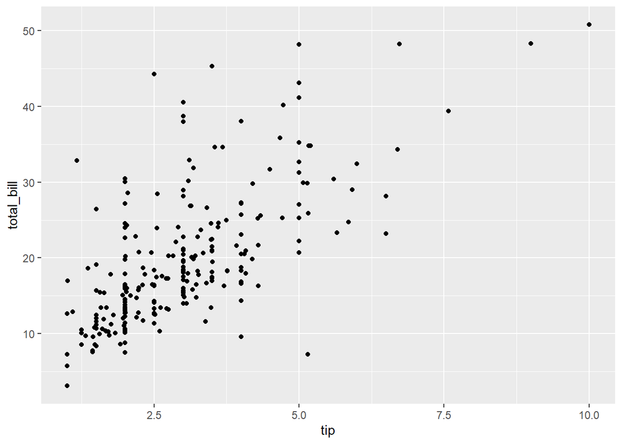

```r
ggplot(tips, aes(tip, total_bill)) + geom_point()
```

After introducing the tiprate variable into the dataset. we can find things like the worst tipper, best tipper, and average tip.

```r
tips$tiprate <- tips$tip / tips$total_bill * 100
head(tips)
```

```
##   total_bill  tip    sex smoker day   time size   tiprate
## 1      16.99 1.01 Female     No Sun Dinner    2  5.944673
## 2      10.34 1.66   Male     No Sun Dinner    3 16.054159
## 3      21.01 3.50   Male     No Sun Dinner    3 16.658734
## 4      23.68 3.31   Male     No Sun Dinner    2 13.978041
## 5      24.59 3.61 Female     No Sun Dinner    4 14.680765
## 6      25.29 4.71   Male     No Sun Dinner    4 18.623962
```

```r
# Best tipper
best_tipper <- tips[which.max(tips$tiprate), ]
best_tipper
```

```
##     total_bill  tip  sex smoker day   time size  tiprate
## 173       7.25 5.15 Male    Yes Sun Dinner    2 71.03448
```

```r
# Worst tipper
worst_tipper <- tips[which.min(tips$tiprate), ]
worst_tipper
```

```
##     total_bill  tip  sex smoker day   time size  tiprate
## 238      32.83 1.17 Male    Yes Sat Dinner    2 3.563814
```

```r
# Average tip rate
mean_tiprate <- mean(tips$tiprate)
mean_tiprate
```

```
## [1] 16.08026
```

there were more males on the high end of tipping and total bill. there was noe corelation between being a smoker or not when it came to the total_bill amount.

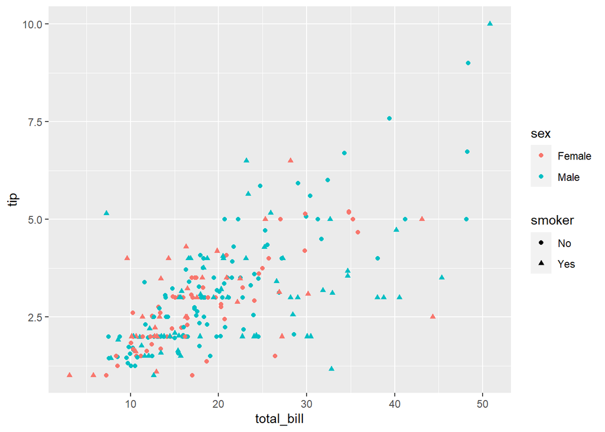

```r
ggplot(tips, aes(x = total_bill, y = tip, color = sex, shape = smoker)) +
  geom_point()
```

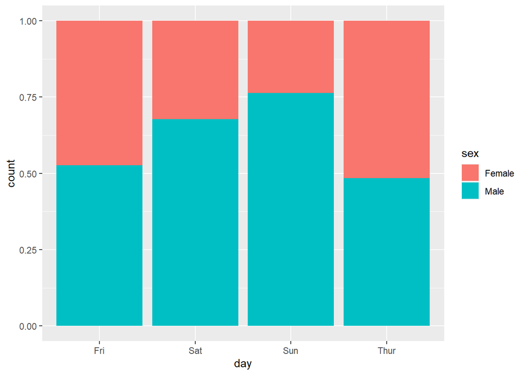

```r
ggplot(tips, aes(x=day, fill=sex)) + geom_bar(position="fill")
```

The best day for tips is on friday because on there were more tips on the third quartile so they were more on the high end. however on sunday is when there is a chance for a super high tip.

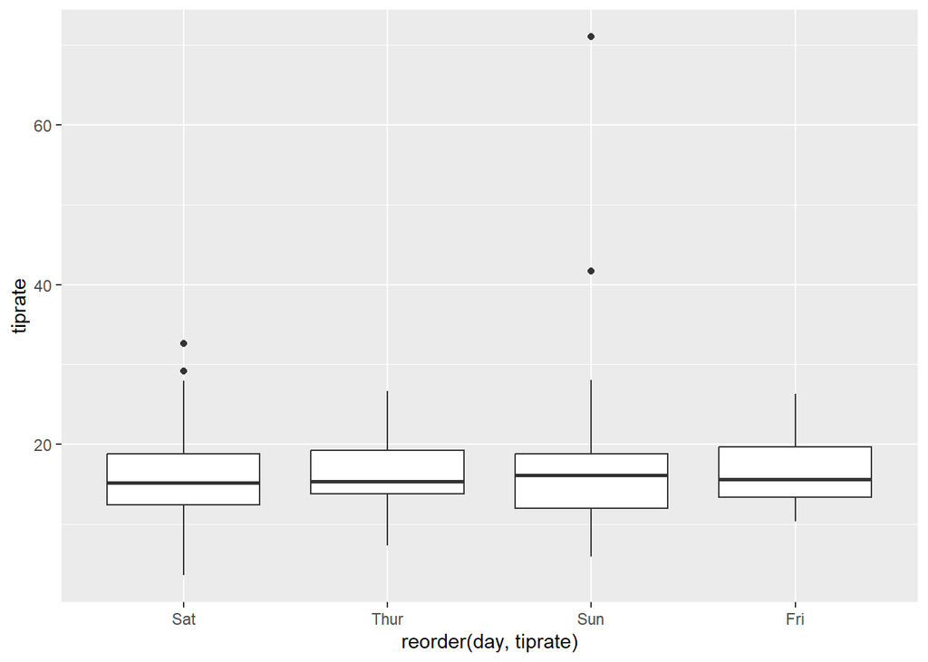

```r
ggplot(tips, aes(x = reorder(day, tiprate), y = tiprate)) +
  geom_boxplot()
```